# elwha-river-salmon-project-final

## Elwha River Dam Removal - Chinook Salmon (*Oncorhynchus tshawytscha*) Recovery Analysis using Python

##### **Introduction**

The Elwha River Dam Removal project serves as a novel case study for river restoration following the removal of large-scale dams. Understanding the impacts of dam removal and the nuances of the changes that follow are crucial for future restoration projects. The Elwha dam was nearly 100 years old when it was removed. The Elwha River Dam was originally completed in 1913 to supply energy to a pulp mill for the region’s booming logging industry. Driven by demand, the Glines Canyon Dam, about 8 miles upstream, followed in 1927 (NPS, 2025). This marked the beginning of what would soon become a national trend. From the 1930s to the 1970s, the United States experienced a dramatic increase in dam building, sometimes referred to as “The Big Dam Era” (Lee, 2023), for benefits such as hydropower, flood control, irrigation, and water supply.

However, later in the 20th century, research began to understand the unforeseen consequences dams often had, such as habitat loss, habitat fragmentation, impacts on fish, reduced sediment transport, and social impacts like displaced communities or livelihoods. The Elwha River was once a thriving salmon habitat with plentiful fish, but dams alter fish migration due to changes in sediment load, hydrologic flow, and changes in water quality, such as temperature, nutrients, and oxygen (U.S. Environmental Protection Agency, 2021). It is estimated that before dam removal, the salmon habitat was reduced by 90% of pre-dam availability due to blocked migration routes. Historical estimates place salmon abundance at around 380,000 to 500,000 annual returns on the Elwha River, whereas a study conducted between 1990 - 2000 found an average of 5,500 salmon annual returns (Pess et al., 2008). This shows a declining trend in salmon in the region since the implementation of the dam. This includes Chinook salmon, a keystone species for the health and stability of the entire ecosystem.

In recent decades, with growing evidence, dam removal is occurring more often in an attempt to restore riparian habitat, natural hydrologic flow, and sediment transport. The dams on the Elwha River became an issue of environmental justice as well, and the Lower Elwha Kallum Tribe was a primary advocate in the push for dam removal. Salmon are a significant part of the lives of the Lower Elwha Klallum people for cultural, spiritual, and physical purposes (Guarino, 2013). After lobbying with additional environmental groups, Congress passed the Elwha River Ecosystem and Fisheries Restoration Act in 1992, and the federal government later purchased the dams. The dam removal process wasn’t completed fully until 2014 (NPS, 2025).

Multiple salmon species, such as the Coho, and trout species, such as Steelhead, are important fish species to the region and to research in the Elwha River restoration project. This data analysis analyzed Chinook salmon recovery specifically due to their cultural significance, keystone species status, ecological importance, and their sensitivity to changes in water quality.

##### **Study Area**

The Elwha River is 45 miles originating in the Olympic Mountains in Washington, U.S., on the Olympic Peninsula, flowing north to the Strait of Juan De Fuca. There were two dams along the Elwha River that were removed. The Elwha Dam removal was completed in 2012, and Glines Canyon Dam was fully removed in 2014. This dam removal project was a huge undertaking, and it was the largest in history at the time. It is estimated to have reopened 75 miles of salmon habitat (U.S. NOAA Fisheries, 2025).

##### **Methods**

This data analysis acquired USGS data from the National Hydrography Dataset (NHD) to retrieve the Watershed Boundary Dataset (WBD) for the Elwha-Dungeness Watershed (HUC8-17110020) at the subbasin level. The polygon was further refined via geospatial processing to just the Elwha watershed data (HUC12) from the entire subbasin polygon. An interactive plot of the Elwha watershed boundary and the defined study area was created. Additionally, the project was originally going to use Global Biodiversity Information Facility (GBIF) data but there were not enough documented occurrences before and after the dam removals in the watershed boundary to get a clear picture of Chinook salmon recovery. A salmonid snorkeling survey dataset was available from USGS snorkeling surveys conducted in 2007/2008 before the dam removal and 2018/2019 after the dam removal.  The USGS salmonid CSV file was downloaded and converted into a pandas dataframe. The columns and dataset were inspected, species codes were verified through the metadata file, and filtered to the species of interest, Chinook (Count_Onts, Fish_km_Onts). The dataset was aggregated by year, count, and density. The river reach data was combined per year for the sum of the total counts of Chinook, and the mean density was calculated across all river reaches. Individual river reach survey data could not be plotted individually due to a lack of consistent coordinate data for the river reaches. The total abundance each year and mean density were plotted on bar and scatter plots, respectively. The Chinook counts and mean density per year were added to the dissolved Elwha watershed polygon. This created a geodataframe with one polygon per year, which was then visualized as an interactive map using hvPlot to show changes before and after the dam removal.

##### **Data Citations**

USGS. (2021). Riverscape snorkeling surveys of salmonid distribution and abundance before (2007, 2008) and after (2018, 2019) dam removal on the Elwha River, Washington [Dataset]. USGS Science Data Catalog

U.S. Geological Survey. Watershed Boundary Dataset (WBD), 8‑digit Hydrologic Unit Code 17110020 — Dungeness‑Elwha. National Geospatial Technical Operations Center, 2025.

### Set-Up

```python
# Import packages for working with files and folders
import os
import pathlib

# Import package for working with geospatial vector data
import geopandas as gpd

# Import package for working with tabular data
import pandas as pd

# Import libaray for plotting
import matplotlib.pyplot as plt

# Import library for working with scientific computation
import numpy as np

# Import library for making interactive plots with vector/tabular data
import hvplot.pandas

# Import library for making interactive plot
import holoviews as hv

# Import library for creating widget slider on plot
import panel as pn
```

### Define Study Area - Elwha River Watershed Boundary Data

```python
# Define project data folder
data_dir = r"C:\Users\nymve\Documents\education\earth-data-analytics\fall-2025\data\WBD_17_HU2_GPKG"

# Make sure the folder exists
os.makedirs(data_dir, exist_ok=True)

# Path to downloaded GeoPackage
wbd_gpkg_path = os.path.join(data_dir, "WBD_17_HU2_GPKG.gpkg")

# Load the HUC12 layer
wbd_gdf = gpd.read_file(wbd_gpkg_path, layer="WBDHU12")

# Inspect columns and first few rows
print(wbd_gdf.columns)

# Inspect the first 5 rows
print(wbd_gdf.head())
```

```
Index(['tnmid', 'metasourceid', 'sourcedatadesc', 'sourceoriginator',
       'sourcefeatureid', 'loaddate', 'referencegnis_ids', 'areaacres',
       'areasqkm', 'states', 'huc12', 'name', 'hutype', 'humod', 'tohuc',
       'noncontributingareaacres', 'noncontributingareasqkm', 'shape_Length',
       'shape_Area', 'hutype_description', 'geometry'],
      dtype='object')
                                    tnmid  \
0  {0E4E6573-8B28-4F8C-B959-694DE3A9F91C}
1  {07FD06B3-4536-4B3D-A598-8D646D308101}
2  {8720D0B0-BEF6-492F-B878-1B0343DB67DD}
3  {F673354E-0002-4C26-8E80-CFA9C84F31AA}
4  {546E09D7-5785-4B5B-A284-634E682D7C41}

                             metasourceid                    sourcedatadesc  \
0  {511D2AC8-11BA-45FC-AB98-F69D693D4C44}  Watershed Boundary Dataset (WBD)
1  {511D2AC8-11BA-45FC-AB98-F69D693D4C44}  Watershed Boundary Dataset (WBD)
2  {511D2AC8-11BA-45FC-AB98-F69D693D4C44}  Watershed Boundary Dataset (WBD)
3  {511D2AC8-11BA-45FC-AB98-F69D693D4C44}  Watershed Boundary Dataset (WBD)
4  {511D2AC8-11BA-45FC-AB98-F69D693D4C44}  Watershed Boundary Dataset (WBD)

                                    sourceoriginator sourcefeatureid  \
0  Natural Resources and Conservation Service and...            None
1  Natural Resources and Conservation Service and...            None
2  Natural Resources and Conservation Service and...            None
3  Natural Resources and Conservation Service and...            None
4  Natural Resources and Conservation Service and...            None

             loaddate referencegnis_ids  areaacres  areasqkm states  ...  \
0 2024-08-15 06:55:45           1148597   12257.36     49.60     OR  ...
1 2024-08-15 06:55:45   1127639,1147060   21300.40     86.20     OR  ...
2 2024-08-15 06:55:45           1519865   17826.81     72.14     CN  ...
3 2024-08-15 06:55:45           1146937   15583.39     63.06     OR  ...
4 2024-08-15 06:55:45     384804,388149   19147.98     77.49     ID  ...

                                  name hutype     humod         tohuc  \
0                           Rock Creek      S        NM  170900050403
1      Stout Creek-North Santiam River      M        NM  170900050602
2                Lower Galbraith Creek      S        NM  170101010306
3  Headwaters North Fork Crooked River      S  DD,IT,CD  170703040308
4      Little Deer Creek-Panther Creek      S        NM  170602031201

  noncontributingareaacres  noncontributingareasqkm  shape_Length  shape_Area  \
0                      0.0                      0.0           NaN         NaN
1                      0.0                      NaN           NaN         NaN
2                      NaN                      NaN           NaN         NaN
3                      0.0                      0.0           NaN         NaN
4                      0.0                      0.0           NaN         NaN

   hutype_description                                           geometry
0            Standard  POLYGON ((-122.44236 44.75208, -122.44279 44.7...
1     Multiple Outlet  POLYGON ((-122.54082 44.83544, -122.54007 44.8...
2            Standard  POLYGON ((-115.22856 49.74735, -115.22856 49.7...
3            Standard  POLYGON ((-120.19341 44.34757, -120.1938 44.34...
4            Standard  POLYGON ((-114.22983 45.20654, -114.2297 45.20...

[5 rows x 21 columns]
```

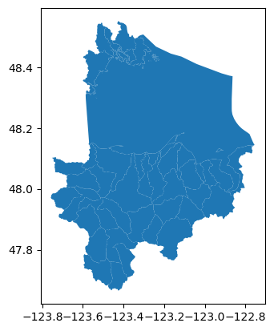

```python
# Filter the Elwha-Dungeness Watershed subbasin HUC8
elwha_gdf = wbd_gdf[wbd_gdf['huc12'].str.startswith("17110020")]

# Rename columns
elwha_gdf = elwha_gdf[['name', 'huc12', 'geometry']].rename(columns={'huc12':'huc'}).set_index('huc')

# Plot the watershed to check data
elwha_gdf.plot()
```

```python
# Check the length
print(len(elwha_gdf))
```

```
39
```

```python
# Print the names of the Elwha HUC12s
print(elwha_gdf['name'])
```

```
huc
171100200604             Mill Stream-Frontal Esquimalt Harbour
171100200601                  Bowker Creek-Frontal Haro Strait
171100200401                                    McDonald Creek
171100200307                             Lower Dungeness River
171100200102               Beckett Point-Frontal Discovery Bay
171100200403                                       Morse Creek
171100200402                                     Siebert Creek
171100200405           Ennis Creek-Frontal Port Angeles Harbor
171100200603        Craigflower Creek-Frontal Victoria Harbour
171100200103                 Eagle Creek-Frontal Discovery Bay
171100200201                             Jimmycomelately Creek
171100200602                                    Colquitz River
171100200514                          Lake Aldwell-Elwha River
171100200101                Salmon Creek-Frontal Discovery Bay
```

[output cut: 26 more lines]

```python
# Look at data
elwha_gdf.head()
```

| huc | name | geometry |
| --- | --- | --- |
| 171100200604 | Mill Stream-Frontal Esquimalt Harbour | MULTIPOLYGON (((-123.50467 48.54219, -123.5047... |
| 171100200601 | Bowker Creek-Frontal Haro Strait | MULTIPOLYGON (((-123.30978 48.49501, -123.3094... |
| 171100200401 | McDonald Creek | POLYGON ((-123.21642 48.12561, -123.21612 48.1... |
| 171100200307 | Lower Dungeness River | POLYGON ((-123.13045 48.15452, -123.13032 48.1... |
| 171100200102 | Beckett Point-Frontal Discovery Bay | POLYGON ((-122.75458 48.14432, -122.75436 48.1... |

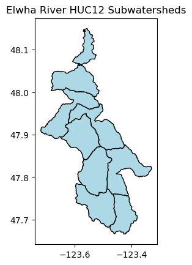

```python
# Filter Elwha HUC12 subwatershed within HUC8 Dungeness-Elwha watershed
elwha_huc12s = [
    "171100200501",
    "171100200502",
    "171100200504",
    "171100200505",
    "171100200507",
    "171100200508",
    "171100200510",
    "171100200512",
    "171100200514",
]

# Create geodataframe and filter for the Elwha HUC12s
elwha_gdf = wbd_gdf[wbd_gdf['huc12'].isin(elwha_huc12s)]

# Select relevant columns and set index
elwha_gdf = elwha_gdf[['name', 'huc12', 'geometry']].rename(columns={'huc12':'huc'}).set_index('huc')

# Plot to check data
elwha_gdf.plot(edgecolor='black', facecolor='lightblue')
plt.title("Elwha River HUC12 Subwatersheds")
plt.show()
```

```python
# Plot the results with web tile images
elwha_gdf_plot = elwha_gdf.hvplot(
    geo=True, tiles='EsriImagery',
    fill_color=None, line_color='white',
    title='Elwha River Watershed (HUC12)',
    frame_width=500)

# Display the plot with esri imagery
elwha_gdf_plot
```

```python
# Check the CRS
print(elwha_gdf.crs)
```

```
EPSG:4269
```

```python
# Save plot as html
hv.save(elwha_gdf_plot, 'elwha_watershed_boundary_map.html')
```

```
WARNING:bokeh.core.validation.check:W-1005 (FIXED_SIZING_MODE): 'fixed' sizing mode requires width and height to be set: figure(id='p1209', ...)
```

### Load USGS Salmon Study Data - Before/After Dam Removal

```python
# Define path to salmon count CSV file
data_dir = r"C:\Users\nymve\Documents\education\earth-data-analytics\fall-2025\data"

# Create directory for CSV
salmon_csv_path = os.path.join(data_dir, "Elwha_Riverscape_reach_data.csv")

# Load tabular data
salmon_df = pd.read_csv(salmon_csv_path)

# Look at the columns and first few rows
print(salmon_df.columns)
print(salmon_df.head())
```

```
Index(['Reach_ID', 'Reach_Code', 'Reach_Name', 'Year', 'Reach_Length_km',
       'Upstream_Reach_Boundary_rkm', 'Downstream_Reach_Boundary_rkm',
       'Section', 'Count_Saco', 'Count_Onxx', 'Count_Onts', 'Count_Onmy',
       'Fish_km_Saco', 'Fish_km_Onxx', 'Fish_km_Onts', 'Fish_km_Onmy', 'JONTS',
       'JONKI', 'JONXX'],
      dtype='object')
   Reach_ID Reach_Code                      Reach_Name  Year  Reach_Length_km  \
0         1       CCGC       Chicago Camp to Godkin Cr  2007            7.531
1         2       GCCC     Godkin Cr to Carlson Canyon  2007            3.983
2         4       HRGR     Hayes River to Goldie River  2007            4.491
3         5       GRRC  Goldie River to Remann's Cabin  2007            2.375
4         6       RCLR    Remann's Cabin to Lost River  2007            0.792

   Upstream_Reach_Boundary_rkm  Downstream_Reach_Boundary_rkm      Section  \
0                    68.626376                      60.823847  Upper Elwha
1                    60.823847                      56.762865  Upper Elwha
2                    53.598804                      49.429491  Upper Elwha
3                    49.429491                      46.700663  Upper Elwha
4                    46.700663                      45.847487  Upper Elwha

   Count_Saco  Count_Onxx  Count_Onts  Count_Onmy  Fish_km_Saco  Fish_km_Onxx  \
0          35         350           0           0      4.647457     46.474572
1          19         529           0           0      4.770274    132.814461
2           7         510           0           0      1.558673    113.560454
3           1          92           0           0      0.421053     38.736842
4           1          88           0           0      1.262626    111.111111

   Fish_km_Onts  Fish_km_Onmy  JONTS  JONKI  JONXX
0           0.0           0.0    NaN    NaN    NaN
1           0.0           0.0    NaN    NaN    NaN
2           0.0           0.0    NaN    NaN    NaN
3           0.0           0.0    NaN    NaN    NaN
4           0.0           0.0    NaN    NaN    NaN
```

```python
# Select columns for Chinook salmon and count
salmon_df = salmon_df[['Reach_ID', 'Reach_Name', 'Year', 'Count_Onts', 'Fish_km_Onts']]

# Rename columns
salmon_df = salmon_df.rename(columns={'Count_Onts':'Chinook_count', 'Fish_km_Onts':'Chinook_per_km'})

# Look at dataframe
salmon_df
```

|  | Reach_ID | Reach_Name | Year | Chinook_count | Chinook_per_km |
| --- | --- | --- | --- | --- | --- |
| 0 | 1 | Chicago Camp to Godkin Cr | 2007 | 0 | 0.000000 |
| 1 | 2 | Godkin Cr to Carlson Canyon | 2007 | 0 | 0.000000 |
| 2 | 4 | Hayes River to Goldie River | 2007 | 0 | 0.000000 |
| 3 | 5 | Goldie River to Remann's Cabin | 2007 | 0 | 0.000000 |
| 4 | 6 | Remann's Cabin to Lost River | 2007 | 0 | 0.000000 |
| ... | ... | ... | ... | ... | ... |
| 77 | 18 | McDonald Bridge to HWY 101 | 2019 | 36 | 24.618751 |
| 78 | 19 | Aldwell Reach | 2019 | 537 | 92.471415 |
| 79 | 20 | Elwha Dam to HWY 112 | 2019 | 39 | 62.400000 |
| 80 | 21 | HWY 112 to One Lane Bridge | 2019 | 282 | 123.792801 |
| 81 | 22 | One Lane Bridge to Mouth | 2019 | 418 | 130.299252 |

82 rows × 5 columns

```python
# Create dataframe with Year and Chinook_count and Chinook_per_km
chinook_year_df = salmon_df[['Year', 'Chinook_count', 'Chinook_per_km']]

# Look at dataframe
chinook_year_df
```

|  | Year | Chinook_count | Chinook_per_km |
| --- | --- | --- | --- |
| 0 | 2007 | 0 | 0.000000 |
| 1 | 2007 | 0 | 0.000000 |
| 2 | 2007 | 0 | 0.000000 |
| 3 | 2007 | 0 | 0.000000 |
| 4 | 2007 | 0 | 0.000000 |
| ... | ... | ... | ... |
| 77 | 2019 | 36 | 24.618751 |
| 78 | 2019 | 537 | 92.471415 |
| 79 | 2019 | 39 | 62.400000 |
| 80 | 2019 | 282 | 123.792801 |
| 81 | 2019 | 418 | 130.299252 |

82 rows × 3 columns

```python
# Aggregate total counts and mean density per year
chinook_year_summary = chinook_year_df.groupby('Year', as_index=False).agg({
    'Chinook_count': 'sum',       # sum the counts (abundance)
    'Chinook_per_km': 'mean'      # take mean of density
})

# Print the new summary dataframe
print(chinook_year_summary)
```

```
   Year  Chinook_count  Chinook_per_km
0  2007            548        4.178448
1  2008            315        5.274970
2  2018           1609       25.752614
3  2019           1937       33.974864
```

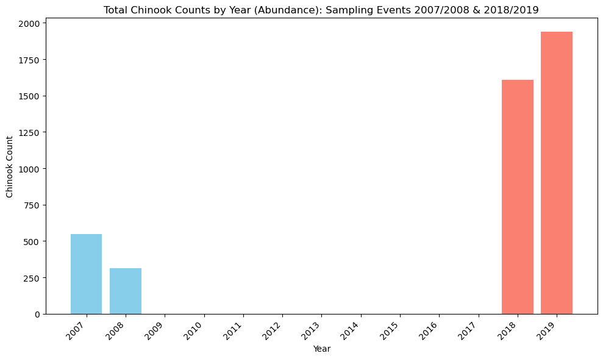

```python
# Plot mean density
abundance_year_subset = chinook_year_summary[chinook_year_summary['Year'].isin([2007, 2008, 2018, 2019])]

# Create simple bar plot to view total abundance data
plt.figure(figsize=(10,6))
plt.bar(abundance_year_subset['Year'], abundance_year_subset['Chinook_count'], color=['skyblue', 'skyblue', 'salmon', 'salmon'])
plt.xticks(ticks=range(2007, 2020), rotation=45, ha='right')
plt.xlabel('Year')
plt.ylabel('Chinook Count')
plt.title('Total Chinook Counts by Year (Abundance): Sampling Events 2007/2008 & 2018/2019')
plt.tight_layout()

# Display the plot
plt.show()
```

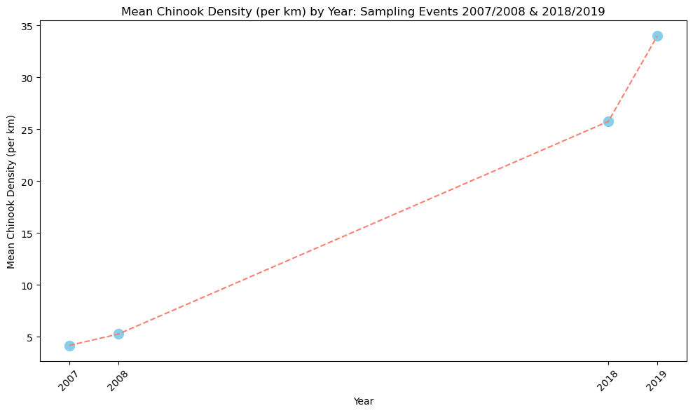

```python
# Plot mean density
density_year_subset = chinook_year_summary[chinook_year_summary['Year'].isin([2007, 2008, 2018, 2019])]

plt.figure(figsize=(10,6))
plt.scatter(density_year_subset['Year'], density_year_subset['Chinook_per_km'], color='skyblue', s=100)  # scatter points

# Connect data points with a line, labels, and add plot parameters
plt.plot(density_year_subset['Year'], density_year_subset['Chinook_per_km'], color='salmon', linestyle='--')
plt.xticks(density_year_subset['Year'], rotation=45)
plt.ylabel('Mean Chinook Density (per km)')
plt.xlabel('Year')
plt.title('Mean Chinook Density (per km) by Year: Sampling Events 2007/2008 & 2018/2019')
plt.tight_layout()

# Display the plot
plt.show()
```

#### Join Watershed Polygon to Chinook Recovery Data

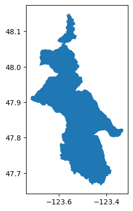

```python
# Dissolve HUC12 watersheds into one watershed
elwha_dissolve = elwha_gdf.dissolve()  # Make a single polygon

# View dissolved polygon
elwha_dissolve.plot()
```

```python
# Add the total salmon counts and density per year to this polygon **Created with the help of ChatGPT***
# This will repeat the polygon for each year
salmon_elwha_watershed_gdf = elwha_dissolve.loc[elwha_dissolve.index.repeat(len(chinook_year_summary))].copy()
salmon_elwha_watershed_gdf['Year'] = chinook_year_summary['Year'].values
salmon_elwha_watershed_gdf['Chinook_count'] = chinook_year_summary['Chinook_count'].values
salmon_elwha_watershed_gdf['Chinook_per_km'] = chinook_year_summary['Chinook_per_km'].values

# View new geodatafram
salmon_elwha_watershed_gdf
```

|  | geometry | name | Year | Chinook_count | Chinook_per_km |
| --- | --- | --- | --- | --- | --- |
| 0 | POLYGON ((-123.41113 47.75506, -123.41075 47.7... | Lake Aldwell-Elwha River | 2007 | 548 | 4.178448 |
| 0 | POLYGON ((-123.41113 47.75506, -123.41075 47.7... | Lake Aldwell-Elwha River | 2008 | 315 | 5.274970 |
| 0 | POLYGON ((-123.41113 47.75506, -123.41075 47.7... | Lake Aldwell-Elwha River | 2018 | 1609 | 25.752614 |
| 0 | POLYGON ((-123.41113 47.75506, -123.41075 47.7... | Lake Aldwell-Elwha River | 2019 | 1937 | 33.974864 |

```python
# Create interactive plot showing salmon before and after dam removal
chinook_year_map = salmon_elwha_watershed_gdf.hvplot(
    geo=True,
    title='Elwha River Chinook Salmon Recovery - Before/After Dam Removal in 2012-2014',
    tiles='EsriImagery',          # Insert underlying map
    color='Chinook_per_km',          # Color by density
    line_width=5,                # Thickness of river line
    hover_cols=['Year', 'Chinook_count', 'Chinook_per_km'], # Info when hovering
    frame_width=700,
    frame_height=500,
    by='Year',                    # Separate layers by year
    slider=True                   # Add a slider
)

# Display the interactive map
chinook_year_map
```

```
WARNING:param.main: slider option not found for polygons plot with bokeh; similar options include: []
```

Note: Due to the polygon being the exact same coordinates for each year, hvplot does not properly update / has a minor bug when you hover the interactive numbers for each year. I was able to correct the issue but it must be viewed in a Jupyter Notebook and was not able to be exported to html.

```python
### Due to holoview identifying the same polygon in geodataframe, a function was created
### Selects new polygon each time slider moves
# Load panel extension
pn.extension('plotly')

# Precompute min/max for consistent color scale and hover
vmin = salmon_elwha_watershed_gdf['Chinook_per_km'].min()
vmax = salmon_elwha_watershed_gdf['Chinook_per_km'].max()

# Create a discrete slider widget for year
year_widget = pn.widgets.DiscreteSlider(
    name='Year',
    options=sorted(salmon_elwha_watershed_gdf['Year'].unique()),
    width=700
)

# Define the plotting function for a single year **Created with help of ChatGPT**
def plot_year(year):
    df = salmon_elwha_watershed_gdf[salmon_elwha_watershed_gdf['Year'] == year].copy()
    return df.hvplot(
        geo=True,
        tiles='EsriImagery',
        color='Chinook_per_km',
        line_width=5,
        hover_cols=['Year', 'Chinook_count', 'Chinook_per_km'],
        frame_width=700,
        frame_height=500,
        title='Elwha River Chinook Salmon Recovery (Before/After Dam Removal 2012-2014)',
        clim=(vmin, vmax),            # consistent color scale & hover details
        hover_line_color='white',
        hover_line_width=3
    )

# Bind the slider to the plotting function
chinook_year_map2 = pn.bind(plot_year, year=year_widget)

# Create layout with plot on top and slider at bottom
pn.Column(
    chinook_year_map2,
    year_widget
)
```

[output not shown]

### **Return of the King: Chinook Salmon Recovery in the Elwha River Watershed following Dam Removals in 2012 - 2014**

Chinook salmon are back and King of the Elwha River once again! In this data analysis using Python, geospatial analysis, and actual snorkeling survey data from USGS, I analyzed the Chinook’s return following a large-scale dam removal. An increase in the total count of Chinook salmon (abundance) over time was observed from the pre-dam removal surveys in 2007/2008 to the post-dam removal surveys in 2018/2019. This could indicate the beginning of a population-scale recovery, and the counts are increasing only a few years after dam removal. This is a positive sign that Chinook salmon are making a return to their former extensive habitat.

An increase in the density of Chinook salmon (per km) was also observed, and the mean density calculated across all river reaches showed a dramatic increase. This indicates the use of the entire habitat surveyed, including areas upstream previously blocked off by the dam. The survey reported that higher densities were seen in previously inaccessible parts of the river, at higher densities than even seen downstream from the dam prior to removal (Torgersen et al., 2021). To clean and visualize these changes, I used data analysis tools such as pandas, geopandas, and hvplot libraries.

Chinook are a keystone species and important food source for both marine and terrestrial apex predators, which in turn impact the entire health and stability of the ecosystem. Chinook are important for nutrient cycling throughout their life cycle. A large amount of wood and sediment was trapped upstream from the dam, and following the dam removal, was released. This release reshaped the riverbed and created new habitat. Sediments are important for salmon breeding; this release likely had an initial disruption on the existing populations downstream, which quickly rebounded (NOAA, 2024). This sediment redistribution also helps with vegetation regrowth.

Indigenous people (Lower Elwha Klallam Tribe) advocated intensely for this dam removal. Chinook salmon are very important culturally, spiritually, and physically, so this salmon recovery has a broader impact socially and economically, not just ecologically (Guarino, 2013). The Chinook recovery improves food security and cultural survival for the tribe.

Some limitations of this analysis included that the coordinate data for individual river reaches were not available, and the snorkeling survey only had four sample events, two years before the dam removal and two years after. There are a lot of possibilities for future analysis to plot the individual counts/densities for each river reach if the proper coordinates for the river reaches were available, which could then be analyzed spatially. Also, plotting a comparison of other salmon and trout species that are vital to a successful restoration project could be valuable. It would also be interesting to plot this salmon recovery alongside water quality, water temperature, or other hydrologic data to compare the increase with those parameters as well.

Overall, the Chinook salmon recovery is not only a story of habitat restoration but also of environmental justice and tribal sovereignty. While benefits from dams like hydropower and flood control are valuable, the impacts on larger ecosystem cycles are too great to be ignored. This data analysis displayed an increase in an important keystone species, the Chinook salmon. Rewilding rivers through dam removal is an important tool in riparian conservation, restoration, and preservation.

##### References

Guarino, J. (2013). Tribal advocacy and the art of dam removal: The Lower Elwha Klallam Tribe’s role in restoring the Elwha River. American Indian Law Journal, 3(2), 1295–1322. https://digitalcommons.law.seattleu.edu/cgi/viewcontent.cgi?article=1295&context=ailj

Lee, G. (2023). Overview: The Big Dam Era. Energy History Online. Yale University. https://energyhistory.yale.edu/the-big-dam-era/

Pess, G. R., McHenry, M. L., Beechie, T. J., & Davies, J. (2008, December 1). Biological impacts of the Elwha River dams and potential salmonid responses to dam removal. Bioone. https://doi.org/10.3955/0029-344X-82.S.I.72

Torgersen, C. E., Duda, J. J., Brenkman, S. J., Peters, R. J., & Sutton, K. T. (2021). Riverscape snorkeling surveys of salmonid distribution and abundance before (2007, 2008) and after (2018, 2019) dam removal on the Elwha River, Washington: U.S. Geological Survey data release. https://doi.org/10.5066/P9MFJXK1

U.S. Environmental Protection Agency. (2021, February). Not stepping in the same river twice: Making strides in ecological restoration through dam removal. https://www.epa.gov/snep/not-stepping-same-river-twice-making-strides-ecological-restoration-through-dam-removal

U.S. National Park Service. (March 28, 2025). History of the Elwha. Olympic National Park. Retrieved December 7, 2025, from https://www.nps.gov/olym/learn/nature/history-of-the-elwha.htm

U.S. National Oceanic and Atmospheric Administration, National Marine Fisheries Service. (2025, June 20). Dam removals on the Elwha River. NOAA Fisheries. https://www.fisheries.noaa.gov/west-coast/dam-removals-elwha-river

U.S. National Oceanic and Atmospheric Administration, Fisheries. (2024, September 5). The Elwha River restoration: A case study in adaptive management for salmon recovery. https://www.fisheries.noaa.gov/feature-story/elwha-river-restoration-case-study-adaptive-management-salmon-recovery